# Final Project

By: Marcus Brooks

**Introduction**

Hello! This Data Science tutorial aims to guide you through all of the phases of the Data Science Pipeline. This will include Data Collection/Curation, Data Management/Representation, Exploratory Data Analysis, Hypothesis Testing and Machine Learning, Communication of Insights Attained.

In this tutorial we used the data containing the Top 1000 Streamers on Twitch from Aayush Mishra on Kaggle (https://www.kaggle.com/aayushmishra1512/twitchdata).

The motivation behind this tutorial is to find out what influences average viewership the most. With this knowledge streamers could identify what metric they need to focus on the most to grow their channel.

**Set Up**

Found below are the packages needed to complete the tutorial. This code will import and install all the necessary dependencies for the tutorial.

```python
import sklearn.model_selection as ms
from sklearn.model_selection import train_test_split
from scipy import stats
from statsmodels.regression.linear_model import WLS
import math
import pandas as pd
import seaborn as sns
import matplotlib.pyplot as plt
import sklearn.model_selection
import sklearn.metrics
from scipy.stats import ttest_rel
from sklearn.ensemble import RandomForestRegressor
from sklearn.model_selection import KFold
from sklearn.linear_model import LinearRegression
from sklearn.metrics import mean_absolute_error
import numpy as np
```

**Data Collection/Curation**

Data collection/curation is the process of gathering the data and getting it into a workable format, such as a DataFrame. This will allow us to have the data in one place and use that data to answer relevant questions and evaluate outcomes.

Importing the Data:

The code below will create a Pandas DataFrame from the CSV (Comma-Separated Values) file provided by Aayush Mishra. A DataFrame is a table with columns and rows. It is very similar to an excel sheet or a SQL table (it's more closely related to the SQL table). A column represents a category of data. A row represents an entry in the table. For example, we can look at the Channel column of the DataFrame and look at the entry in row 0 for the column Channel. This entry is xQcOW. So we can see that this column stores the channel name for each entry.

For more information regarding DataFrames, check out this link: https://www.datacamp.com/community/tutorials/pandas-tutorial-dataframe-python.

```python
df = pd.read_csv("./twitchdata-update.csv",
                low_memory=False)
df
```

|  | Channel | Watch time(Minutes) | Stream time(minutes) | Peak viewers | Average viewers | Followers | Followers gained | Views gained | Partnered | Mature | Language |
| --- | --- | --- | --- | --- | --- | --- | --- | --- | --- | --- | --- |
| 0 | xQcOW | 6196161750 | 215250 | 222720 | 27716 | 3246298 | 1734810 | 93036735 | True | False | English |
| 1 | summit1g | 6091677300 | 211845 | 310998 | 25610 | 5310163 | 1370184 | 89705964 | True | False | English |
| 2 | Gaules | 5644590915 | 515280 | 387315 | 10976 | 1767635 | 1023779 | 102611607 | True | True | Portuguese |
| 3 | ESL_CSGO | 3970318140 | 517740 | 300575 | 7714 | 3944850 | 703986 | 106546942 | True | False | English |
| 4 | Tfue | 3671000070 | 123660 | 285644 | 29602 | 8938903 | 2068424 | 78998587 | True | False | English |
| ... | ... | ... | ... | ... | ... | ... | ... | ... | ... | ... | ... |
| 995 | LITkillah | 122524635 | 13560 | 21359 | 9104 | 601927 | 562691 | 2162107 | True | False | Spanish |
| 996 | 빅헤드 (bighead033) | 122523705 | 153000 | 3940 | 793 | 213212 | 52289 | 4399897 | True | False | Korean |
| 997 | 마스카 (newmasca) | 122452320 | 217410 | 6431 | 567 | 109068 | -4942 | 3417970 | True | False | Korean |
| 998 | AndyMilonakis | 122311065 | 104745 | 10543 | 1153 | 547446 | 109111 | 3926918 | True | False | English |
| 999 | Remx | 122192850 | 99180 | 13788 | 1205 | 178553 | 59432 | 2049420 | True | False | French |

1000 rows × 11 columns

**Data Management/Representation**

Now, we must check if the DataFrame has any missing values. These missing values could be represented as nan. The code below checks the data frame to see if any nan values exist within any column and row.

```python
df.isnull().values.any()
```

```
False
```

It would seem that our DataFrame doesn't have any nan values, so there is no missing data! This is a nice outcome, but this isn't always the case.

In the case of missing data, there are a few things that you can do:

1. Remove all rows with missing data
2. Impute the missing data

-Removing all the rows with missing data-

This can have different effects depending on why your data is missing.

There are three types of missingness:

```
Missing Completely at Random (MCAR) - The probability that the data is missing is not dependent on any of the data, observed or unobserved.

Missing at Random (MAR) - The probability of missing data is dependent on the observed data but not on the unobserved data.

Missing Not at Random (MNAR) - The reason the data is missing is because of the data itself. (For example, someone not wanting to answer about whether they have committed a crime or not, due to the social effects of answering that question truthfully if you have committed a crime)
```

-Imputing the missing data-

Imputation is the process of substiuting values in for missing data. There are multiple forms of imputation:

```
Single imputation:

Mean imputation: imputing the average from observed cases for
all missing values of a variable

Hot-deck imputation: imputing a value from another subject that is most like the subject in terms of observed
variables

Cold-deck imputation: missing values are replaced by values from another data set
```

However, all of these methods impose too much precision, have uncertainty over what unobserved values actually are, and were developed before cheap computation.

Multiple imputation was developed to deal with noise during imputation. Multiple imputation generates multiple random values for each missing value during the imputation.

For more information regarding imputation, check out this link: https://www.theanalysisfactor.com/seven-ways-to-make-up-data-common-methods-to-imputing-missing-data/.

**Exploratory Data Analysis**

Exploratory Data Analysis (EDA) is the process of analyzing data sets to determine their characteristics. This is commonly done with data visualization methods. Exploratory Data Analysis aims to look at what the data can tell us beyond what is explored during the Hypothesis Testing phase. Often times this phase of the data science pipeline will allow us to discover patterns in the data that we might want to explore further. This process also allows us to check our assumptions that we had about the data. It is a good idea to try to understand the data first and get as many insights as possible before diving into the hypothesis testing phase.

For more information on Exploratory Data Analysis, check out this link: https://towardsdatascience.com/exploratory-data-analysis-8fc1cb20fd15.

Below is the code necessary to create what is called a "Spearman Correlation Matrix". This matrix allows us to see the correlation between our columns! We'll consider a strong correlation anything above the value 0.5.

The brighter the color is for a correlation, the stronger the correlation is. We can see this by looking at all the values on the diagonal. These values are 1 and cream colored because each column is directly correlated with itself. Negative correlations are very dark. This can be seen by looking at the correlation between average viewers and Stream time, which has a value of -0.5.

[output not shown]

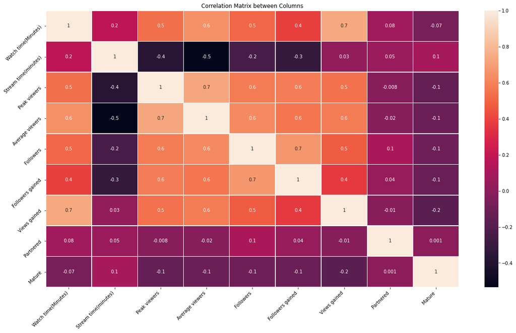

```python
#create the heat map
plt.subplots(figsize = (20,11))
g = sns.heatmap(df.corr("spearman"), annot = True, fmt = '.1g', linewidths=.5,)

#Set the labels for the heat map
g.set_title("Correlation Matrix between Columns")
g.set_xticklabels(g.get_xticklabels(), rotation=45, horizontalalignment='right')
g.set_yticklabels(g.get_yticklabels(), rotation=45, horizontalalignment='right')
```

Some noteable correlations here are the strong correlations between Average Viewers and Watch Time, Followers, Followers Gained, and Views Gained. These all have a value over 0.5 for correlation. We decided not to use Peak Viewers because the data is too similar to Average Viewers, in the sense that the data is not independent from Average Viewers.

**Hypothesis Testing**

Hypothesis Testing is when you form some kind of theory or argument that explains some observed phenomenon within the data and you seek to prove or disprove this theory through experimentation. A crucial part of hypothesis testing is forming the null hypothesis (something you seek to disprove) and an alternative hypothesis (something you seek to prove).

In this tutorial our null hypothesis will be that Watch Time(Minutes) is the best single column predictor of Average Viewers.

Our alternative hypothesis will be that Watch Time (Minutes) is not the best single column predictor of Average Viewers.

We chose this column to form our hypothesis around because Watch Time should be heavily correlated with Average Viewers. If you have a high amount of average viewers, you are likely to have a higher watch time.

For more information on Hypothesis Testing, check out this link here: https://www.section.io/engineering-education/hypothesis-testing-data-science/.

Lets take a look at some scatter plots and fit a linear regression on each to get a better understanding of what our column's relationship with Average Viewers looks like.

```python
df2 = df

lm = LinearRegression()

#set the independent and dependent variables for the linear regression fit
ind = [[x] for x in df2['Watch time(Minutes)']]
dep = df2["Average viewers"]

#fit the linear regression
lm.fit(ind, dep)
```

```
LinearRegression()
```

```python
#create a new column in the dataframe for the watch time residuals
df2['watch residuals'] = df2['Average viewers'] - lm.predict(ind)
```

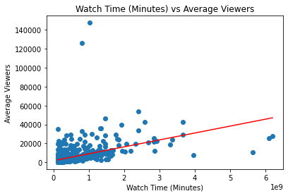

```python
#plot the watch time vs average viewers
plt.scatter(x=df['Watch time(Minutes)'], y=df["Average viewers"])

#plot the linear regression
plt.plot(ind, lm.predict(ind), "r")

#set the labels and title for the plot
plt.title("Watch Time (Minutes) vs Average Viewers")
plt.xlabel("Watch Time (Minutes)")
plt.ylabel("Average Viewers")
```

This plot seems to have a few outliers. These can be seen in the top left side of the plot, as well as in the bottom right corner. Lets remove those outliers and see what the plot looks like then!

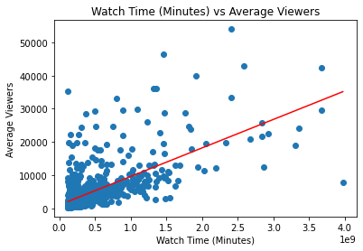

```python
#drop the outliers for the watch time column
for i in range(1,4):
    toDrop = df2['Watch time(Minutes)'].idxmax()
    df2 = df2.drop(axis = 0, index = toDrop)

#drop the outliers for the average viewers column
for i in range(1,3):
    toDrop = df2['Average viewers'].idxmax()
    df2 = df2.drop(axis = 0, index = toDrop)

ind = [[x] for x in df2['Watch time(Minutes)']]
dep = df2["Average viewers"].tolist()

lm.fit(ind, dep)

plt.scatter(x=df2['Watch time(Minutes)'], y=df2["Average viewers"])
plt.plot(ind, lm.predict(ind), "r")
plt.title("Watch Time (Minutes) vs Average Viewers")
plt.xlabel("Watch Time (Minutes)")
plt.ylabel("Average Viewers")
```

This plot is much easier to look at. Previously the outliers caused the plot to be very zoomed out and it caused a lot of overlap of points on the plot. Removing the outliers also has an effect on the linear regression, making the linear regression more accurate by allowing the linear regression to represent the bulk of the data instead of being influenced by a few outliers.

Lets take a look at the residuals of this plot. A residual is the difference between the predicted value and the actual value itself. Since we have the predicted value and the real value, we can calculate this and form a scatter plot of the residuals! We can see this scatter plot below.

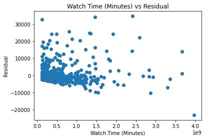

```python
plt.scatter(df2['Watch time(Minutes)'], df2['watch residuals'])
plt.title("Watch Time (Minutes) vs Residual")
plt.xlabel("Watch Time (Minutes)")
plt.ylabel("Residual")
```

Oh no! It looks like our data is heteroscedastic. This is when the points on the plot spread out to form a cone shape as the x value increases. This can cause problems when running a linear regression. If we look at the plots for the rest of the columns below, we can see that many of them have this cone shape to them, and so then do their residuals. Lets switch to a different approach to showing the relationship between these columns and average viewership.

For more information on heteroscedasticity, you can check out this resource here: https://statisticsbyjim.com/regression/heteroscedasticity-regression/.

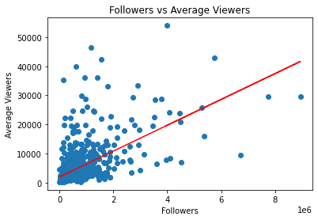

```python
lm = LinearRegression()

ind = [[x] for x in df2['Followers']]
dep = df2["Average viewers"]

lm.fit(ind, dep)

plt.scatter(x=df2['Followers'], y=df2["Average viewers"])
plt.plot(ind, lm.predict(ind), "r")
plt.title("Followers vs Average Viewers")
plt.xlabel("Followers")
plt.ylabel("Average Viewers")
```

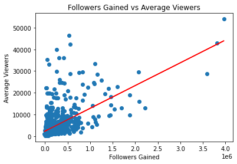

```python
lm = LinearRegression()

ind = [[x] for x in df2['Followers gained']]
dep = df2["Average viewers"]

lm.fit(ind, dep)

plt.scatter(x=df2['Followers gained'], y=df2["Average viewers"])
plt.plot(ind, lm.predict(ind), "r")
plt.title("Followers Gained vs Average Viewers")
plt.xlabel("Followers Gained")
plt.ylabel("Average Viewers")
```

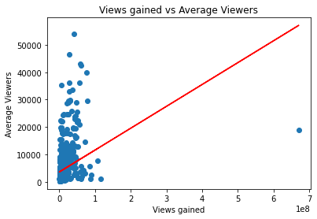

```python
lm = LinearRegression()

ind = [[x] for x in df2['Views gained']]
dep = df2["Average viewers"]

lm.fit(ind, dep)

plt.scatter(x=df2['Views gained'], y=df2["Average viewers"])
plt.plot(ind, lm.predict(ind), "r")
plt.title("Views gained vs Average Viewers")
plt.xlabel("Views gained")
plt.ylabel("Average Viewers")
```

**Machine Learning**

We can use machine learning to see which of these columns is the best predictor of average viewers. In order to do this we'll use the Random Forest Regressor. First we'll identify which data is our independent data and which data is our dependent data. Well, the Watch Time, Followers, Followers Gained, and Views Gained columns will be our independent data and our dependent data will be our average viewers.

Next we'll want to split our data into training data and test data. Now we'll have four sets of data: training independent data, training dependent data, test independent data, and test dependent data. We'll train our model (the Random Forest Regressor) on the training data and then use the test data to see how good our model is at making predictions. Afterwards, we'll calculate the mean absolute error of each prediction and compare them to see which column is the best predictor.

Note: You can tell which column(s) are being used to fit the regression by looking at what column(s) the ind variable is being set to.

Watch time(Minutes):

```python
ind = df['Watch time(Minutes)']
dep = df['Average viewers']

rf = RandomForestRegressor()

#split our data into training and testing sets
ind_train, ind_test, dep_train, dep_test = ms.train_test_split(ind, dep)
ind_train = [[x] for x in ind_train]
ind_test = [[x] for x in ind_test]

#fit the regressor with the training sets
fit = rf.fit(ind_train, dep_train)

#compute the mean absolute error with the test sets
predicted = rf.predict(ind_test)
actual = np.array(dep_test)
mean_absolute_error(actual, predicted)
```

```
4235.960120000001
```

```python
mean_absolute_error(actual, predicted) / np.mean(actual) * 100
```

```
69.33839353411757
```

Followers:

```python
ind = df['Followers']
dep = df['Average viewers']

rf = RandomForestRegressor()
ind_train, ind_test, dep_train, dep_test = ms.train_test_split(ind, dep)
ind_train = [[x] for x in ind_train]
ind_test = [[x] for x in ind_test]
rf.fit(ind_train, dep_train)
predicted = rf.predict(ind_test)
actual = np.array(dep_test)
mean_absolute_error(actual, predicted)
```

```
3120.1072799999997
```

```python
mean_absolute_error(actual, predicted) / np.mean(actual) * 100
```

```
69.78887979278782
```

Followers gained:

```python
ind = df['Followers gained']
dep = df['Average viewers']

rf = RandomForestRegressor()
ind_train, ind_test, dep_train, dep_test = ms.train_test_split(ind, dep)
ind_train = [[x] for x in ind_train]
ind_test = [[x] for x in ind_test]
rf.fit(ind_train, dep_train)
predicted = rf.predict(ind_test)
actual = np.array(dep_test)
mean_absolute_error(actual, predicted)
```

```
4199.603546666667
```

```python
mean_absolute_error(actual, predicted) / np.mean(actual) * 100
```

```
77.46808099843402
```

Views gained:

```python
ind = df['Views gained']
dep = df['Average viewers']

rf = RandomForestRegressor()
ind_train, ind_test, dep_train, dep_test = ms.train_test_split(ind, dep)
ind_train = [[x] for x in ind_train]
ind_test = [[x] for x in ind_test]
rf.fit(ind_train, dep_train)
predicted = rf.predict(ind_test)
actual = np.array(dep_test)
mean_absolute_error(actual, predicted)
```

```
3300.2787200000002
```

```python
mean_absolute_error(actual, predicted) / np.mean(actual) * 100
```

```
78.08878276021008
```

The error for each of these columns appears to be quite high. Perhaps the Average viewers is not dependent on a single column but is instead multi-variate, in that it is dependent on multiple columns. Lets try to fit the regressor with data from all of the columns we are looking at.

Watch time(Minutes), Followers, Followers gained, Views gained:

```python
#This ind initialization targets all of the columns specified within it
ind = df[['Watch time(Minutes)', 'Followers', 'Followers gained', 'Views gained']]
dep = df['Average viewers']

rf = RandomForestRegressor()

#split the data frame into two data frames, one for testing, and one for training
train, test = ms.train_test_split(df, test_size=0.5)

#create training and testing sets from the training and testing dataframes respectively
ind_train = train[['Watch time(Minutes)', 'Followers', 'Followers gained', 'Views gained']]
ind_test = test[['Watch time(Minutes)', 'Followers', 'Followers gained', 'Views gained']]
dep_train = train['Average viewers']
dep_test = test['Average viewers']

#fit the regressor with the training sets
rf.fit(ind_train, dep_train)

#calculate mean absolute error with the test sets
predicted = rf.predict(ind_test)
actual = np.array(dep_test)
mean_absolute_error(actual, predicted)
```

```
2615.67484
```

```python
mean_absolute_error(actual, predicted) / np.mean(actual) * 100
```

```
57.43287993191514
```

This resulted in a better prediction. Which leads us to believe that the data is indeed multi-variate. Let's do a fit with all of the numeric columns of the data frame and see if that leads to an even better prediction.

Watch time(Minutes), Stream time(minutes), Peak viewers, Followers, Followers gained, Views gained:

```python
ind = df[['Watch time(Minutes)', 'Stream time(minutes)', 'Peak viewers', 'Followers', 'Followers gained', 'Views gained']]
dep = df['Average viewers']

rf = RandomForestRegressor()

train, test = ms.train_test_split(df, test_size=0.5)

ind_train = train[['Watch time(Minutes)', 'Stream time(minutes)', 'Peak viewers', 'Followers', 'Followers gained', 'Views gained']]
ind_test = test[['Watch time(Minutes)', 'Stream time(minutes)', 'Peak viewers', 'Followers', 'Followers gained', 'Views gained']]
dep_train = train['Average viewers']
dep_test = test['Average viewers']

rf.fit(ind_train, dep_train)

predicted = rf.predict(ind_test)
actual = np.array(dep_test)
mean_absolute_error(actual, predicted)
```

```
1286.84788
```

```python
mean_absolute_error(actual, predicted) / np.mean(actual) * 100
```

```
27.621803154967406
```

This resulted in an even better prediction! It would seem that Average Viewers isn't dependent on a single column, but lets continue to see if Watch Time is the best single column predictor among the columns we chose to look at.

This approach only shows the results of a single attempt to train and test based on each column. The results could be different with each run of these tests, so are we certain that these scores are truly accurate?

Lets try a different approach. Let's use KFold to provide train and test indices to split the data into training and testing sets. KFold will the split the data into k folds. Each fold is used as a test set once while the remaining k - 1 folds are used to create the training set. It does this k times. In this tutorial, we'll make k equal to 10. We'll print the score of each prediction and then calculate the mean of those scores. The best score is a 1.0. So the closer the mean score is to 1.0, the better it is!

Note: You can tell which column(s) are being used to fit the regression by looking at what column(s) the X variable is being set to.

Watch time(Minutes):

```python
#initialize the scores array as an empty array to later fill with scores to calculate the mean score
scores = []

#create the KFold and specify the number of splits (10)
kf = KFold(n_splits=10)

#initialize the independent variable (X) and the dependent variable (y)
X = df['Watch time(Minutes)']
y = df['Average viewers']

#this loop uses kf.split to creat training indices and test indices and then we use those to create training sets and
#testing sets. We then fit our regressor with the training set and then test on score our regressor on how it does with the
#testing set. We append the score to the scores array.
for train_index, test_index in kf.split(X):
    X_train, X_test = X[train_index], X[test_index]
    X_train = [[x] for x in X_train]
    X_test = [[x] for x in X_test]
    Y_train, Y_test = y[train_index], y[test_index]

    rf.fit(X_train, Y_train)
    print(rf.score(X_test, Y_test))
    scores.append(rf.score(X_test, Y_test))

#calculate and print the mean score
print("Mean score:")
np.mean(scores)
```

```
-0.19347047178889665
0.045814239144506774
0.01223485509811939
-0.029635696929669164
-0.14231640893841835
-0.09085641037685055
-0.0717536143341444
-0.9511631425639162
-0.04853487361742581
-0.008091079434878301
Mean score:
```

```
-0.14777726037415734
```

Followers:

```python
scores = []

kf = KFold(n_splits=10)
X = df['Followers']
y = df['Average viewers']
for train_index, test_index in kf.split(X):
    X_train, X_test = X[train_index], X[test_index]
    X_train = [[x] for x in X_train]
    X_test = [[x] for x in X_test]
    Y_train, Y_test = y[train_index], y[test_index]

    rf.fit(X_train, Y_train)
    print(rf.score(X_test, Y_test))
    scores.append(rf.score(X_test, Y_test))
print("Mean score:")
np.mean(scores)
```

```
-0.26854261414964387
-0.14247546091918828
-1.2363077546040366
-0.051896253827999006
-0.4916054258121094
-7.487760037011045
-0.5872955209961062
-4.907840029492593
-2.6512742218946186
-0.3455483993137596
Mean score:
```

```
-1.8170545718021096
```

Followers gained:

```python
scores = []

kf = KFold(n_splits=10)
X = df['Followers gained']
y = df['Average viewers']
for train_index, test_index in kf.split(X):
    X_train, X_test = X[train_index], X[test_index]
    X_train = [[x] for x in X_train]
    X_test = [[x] for x in X_test]
    Y_train, Y_test = y[train_index], y[test_index]

    rf.fit(X_train, Y_train)
    print(rf.score(X_test, Y_test))
    scores.append(rf.score(X_test, Y_test))
print("Mean score:")
np.mean(scores)
```

```
-0.5392110743397602
-0.526348865975335
-0.5190356625298316
-0.6610364098165933
-0.5460902572814035
-23.004445861305772
-0.4570637592957201
-4.4100493103014555
-1.4096709597254606
-0.7262971603321928
Mean score:
```

```
-3.2799249320903527
```

Views gained:

```python
scores = []

kf = KFold(n_splits=10)
X = df['Views gained']
y = df['Average viewers']
for train_index, test_index in kf.split(X):
    X_train, X_test = X[train_index], X[test_index]
    X_train = [[x] for x in X_train]
    X_test = [[x] for x in X_test]
    Y_train, Y_test = y[train_index], y[test_index]

    rf.fit(X_train, Y_train)
    print(rf.score(X_test, Y_test))
    scores.append(rf.score(X_test, Y_test))
print("Mean score:")
np.mean(scores)
```

```
-0.46712951704773964
-0.08780813454102465
-0.8285902162212024
-4.91899379152305
-1.8838426754679238
-3.05484918109968
-2.276729379175016
-1.8605282316995768
-0.22870617974564977
-1.2297272154537389
Mean score:
```

```
-1.6836904521974603
```

**Communication of Insights Attained**

This phase of the Data Science pipeline is where we get to communicate all of our findings from our hypothesis testing phase.

Based on the results of the Mean Absolute Error test as well as the results we got from our score() function during our KFold, it would appear that Watch Time is the best predictor of Average Viewers. This means that we cannot reject our null hypothesis of Watch Time (Minutes) being the best predictor of Average Viewers and we must accept this null hypothesis.

Depsite accepting our null hypothesis of Watch Time being the best single column predictor of Average Viewers, it would seem we would get better predictions if we trained our data using all of the numeric columns. We may get an even better prediction if we trained using all of the columns together! However, some columns are categorical in nature, so we'd have to do Dummy Encoding or some other method of dealing with categorical data.

Check our this link for more information on what categorical data is and how to deal with it: https://www.analyticsvidhya.com/blog/2020/08/types-of-categorical-data-encoding/.

Perhaps as an exercise you could use one of these encodings to convert your catergorical data to numeric data and see if it leads to a better prediction of average viewers!

I hope that this guide has been helpful in understanding the data science pipeline. Good luck in your Data Science endeavors!